# Predicting Movement Using Sensors

Paul Stey

September 26, 2015

# 1 Introduction

The current project aims to build a model to be used for classifying movements based on sensor data. In particular, using the Weight Lifting Exercise (WLE) data from Velloso and colleagues, (2013), we will attempt to predict the manner in which the user was exercising. Thus, our outcome variable, `classe`, is the variable for which we are building a model. The goal will be a model that most accurately predicts the `classe` variable using the many sensor measurement as predictors.

# 2 Data Import and Cleaning

We begin by importing our data and getting a few quick summaries of the variable. An important point to keep in mind when importing the data is that missing values seem to take several forms in the raw data set. That is, they can appear as simply blank spaces, they can appear as “NA” in the cell, and they can also appear as “#DIV/O!”. This last form is of concern to us, because R will not immediate recognize this as needing to be treated as NA. And as a result, variables with this value would be imported and treated as factors. A reasonable way to handle this is by explicitly specifying the `na.strings` argument when calling `read.csv()`. In particular, we could want to specify `na.strings = c("", "NA"", "#DIV/0!")`. This will ensure all three forms of missing data are treated as `NA`.

Once we have imported the data, a call to `dim()` reveals we have over 16600 observations, and over 150 predictor variables. Calling `summary()` provides a bit of insight into the nature of the variables. We have almost exclusively numeric variables—these are the recorded measurements from the sensors—but we also have several factor variables. Notably, the `user_name` and `classe` variables are factors.

The call to `summary()` also reveals that we have considerable missingness in certain variables. In particular, it seems that a substantial number of variables are calculated values based on the raw measurement data. For instance, consider the variable `avg_pitch_dumbbell`. This variable has almost exclusively `NA` values, and it seems that it is just a summary statistic calculated on the prior measurements in that movement “window”. We note also the `new_window` variable. This seems to indicate when a new movement is being initiated, and thus, where the summary values have been calculated.

Next, we proceed with cleaning the data prior to any model fitting. First, we remove the various time-stamp variables. Without knowing more about the study design, it is not obvious that these variables can be trusted for making predictions in a test set.

Next, since many of the model fitting functions we plan to use do not handle missing data natively, we clean our data set so as to eliminate predictor variables with `NA` values. We elect to remove predictors with `NA` values rather than observations with `NA` values—that is, case-wise deletion—because the latter would reduce our complete training data set to less than 500 observations.

It is important to note that the variables we are excluding are summary variables calculated on the raw sensor values, which we will be keeping. This makes us more comfortable with the notion of deleting many predictors in what could seem to be an arbitrary fashion.

In order to help us, we write a quick function to flag those predictors we wish to exclude from our model fitting data.

```r
exclude <- function(dat) {
    p <- ncol(dat)                              # dat is our full dataset
    exclude <- rep(FALSE, p)
    for (j in 1:p) {
        if (any(is.na(dat[, j]))) {
            exclude[j] <- TRUE
        }
    }
    return(exclude)
}

d <- d[, !exclude(d)]                           # keep cols with zero NAs
```

After running this function we are left with many fewer predictors, but we still have all the raw sensor measurements.

One final cleaning step is to exclude those observations for which the `new_window` value is equal to “yes”. We do this simply because a quick glance at the test set reveals that all the data in the test set have `new_value` equal to “no”. Thus, including this in our model building as though it were a candidate predictor could be misleading, since it has no variability in the test set.

# 3 Model Building Strategy

We use the `caret` package for model fitting. This has the advantage of giving us access to many popular machine learning packagages (e.g., `randomForest`, `glmnet`, `kernlab`) that are “under the hood” in `caret`, while still giving them a common syntax and interface.

Prior to model fitting, we can take advantage of our large training set to get a very realistic idea of the accuracy of our eventual classifier. In particular, we can split our training set itself into a training and test set. Thus, we split our original training set into 60% training set and 40% hold-out training set. We use the 10000 or so observations in our training set to build and select our model and its optimal tuning parameters. Then we use our fitted model to predict the `classe` variable in our hold-out training set. Comparing our predictions against the actual values in our hold-out training set gives us an additional estimate of our test error—that is, in addition to training error and cross-validation error.

We use 5-fold cross-validation to estimate the accuracy of our various models, as well as the optimal tuning parameters for those models.

# 4 Candidate Models

We consider three classes of models: random forest, gradient boosted trees, and support vector machines with radial basis kernel. These candidate models are being considered because they are widely regarded as some of the better “off-the-shelf” prediction models. Additionally, random forests and boosted trees have the advantage of being very well suited to data where predictors interact. And because of the data in question, we might well expect *a priori* that the measurements at the various sensors are likely to interact.

Of course, random forests have the very practical advantage that the model fitting process is perfectly suitted to parallelization. This allows us to take advantage of multi-core CPUs to speed up our computation. But in all cases, we can take advantage of the `caret` package and the `doMC` package to run the cross-validation folds in parallel.

## 4.1 Random Forest

We begin with random forests. Another one of the many reasons this model fitting approach is so popular is because there are very few tuning parameters. In general, we would have two: the number of trees, and the number of predictors to consider at a given split, called `mtry` in many software packages. But in the case of the random forest implementation in the `caret` packages, the only tuning parameter is the latter. The package uses an adaptive monitoring scheme to discontinue the iterations (i.e., building trees) once a threshold is reached.

Thus, we prepare a very simple tuning grid that consists of only a single matrix of `mtry` values.

```r
rf_grid <- expand.grid(
    mtry = c(2, 10, 20, 30, 40, 50)
)
```

We then run this using 5-fold cross validation. The results of the models are illustrated in the figure below. As this indicates, all the random forest models showed very impressive classification accuracy. In all cases, the mean classification accuracy accross CV folds was at least 98%. This is excellent.

Also noteworth is that the optimal `mtry` value for these training data appeared to be 10. That is, for each candidate spilt when building a tree, the optimal model was the one that considered a subset of only 10 of the total predictors. It is worth noting, though, that the models using other `mtry` values also performed very well.

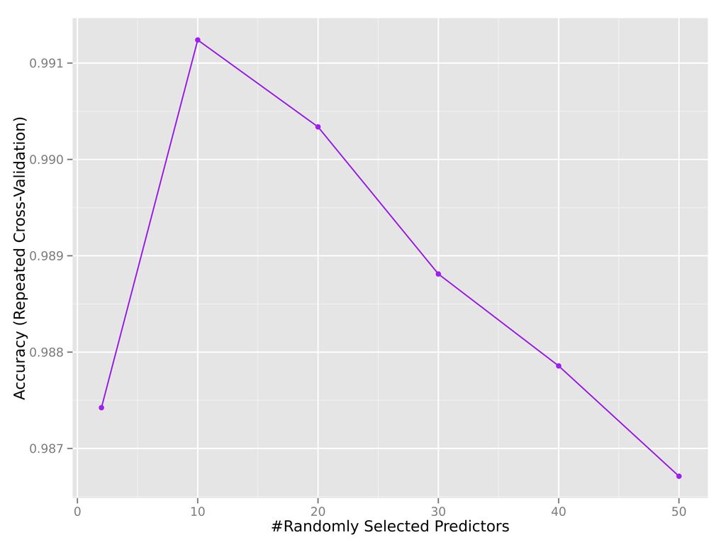

Lastly, we use our additional hold-out training data to get another estimate of our classification accuracy. Because we set this aside prior to model fitting, we can expect the classification accuracy here to be very similar to what we would observe in our test set.

Thus, we take our fitted model and use the `predict()` function to generate our model-predicted values for the `classe` variable. Finally, we compare this to the *actual* values of the `classe` variable in the hold-out training data. For the optimal random forest model, the classification accuracy in our hold out training data was 99.14%. Again, this is a very impressive value, and we are also comforted to see that it closely matches the value of our optimal model’s CV classification accurary.

## 4.2 Gradient Boosted Trees

Next we proceed with another ensemble-type model: boosted trees. This method is similar to random forests in that it takes many “weak” classifiers and uses the combination to produce a remarkably powerful model for prediction. Like random forests, this aggregation of weak classifiers helps boosting to very desirable balance of bias and variance.

Unlike random forests, however, the boosting process requires that the various classifiers are fitted in serial. Thus, we can only take advantage of our CPUs multiple cores for the parallelization of cross-validation folds.

We again prepare a grid of combinations of tuning parameters. In the case of our boosting model, we vary the interaction depth from 1 to 15 and the number of trees from 50 to 1000. We also fit the shrinkage parameter to 0.1 and the minimum number of observations in a leaf is fixed at 20.

```r
gbm_grid <- expand.grid(
    interaction.depth = c(1, 5, 10, 15),
    n.trees = c(50, 100, 500, 1000),
    shrinkage = 0.1,
    n.minobsinnode = 20
)
```

After running 5-fold cross validation, we observe that all tuning parameter combinations did quite well. This is illustrated in the figure below. With the exception of the boost “stump” model, all models did quite well even after only 100 boosting iterations. All models with interaction depth greater than 1 arrive at above 95% classification accuracy after even 100 trees, and by 500 trees these are all above 99% accuracy.

Cross validation found the optimal meta-parameter combination to be 1000 boosting iterations and an interaction depth of 15. This was our final model. And as we did with the final random forest model, we use the fitted boosting model to predict the values in our hold-out training data. This revealed a prediction accuracy of 99.71%. This is excellent, and also slightly better than the best random forest model.

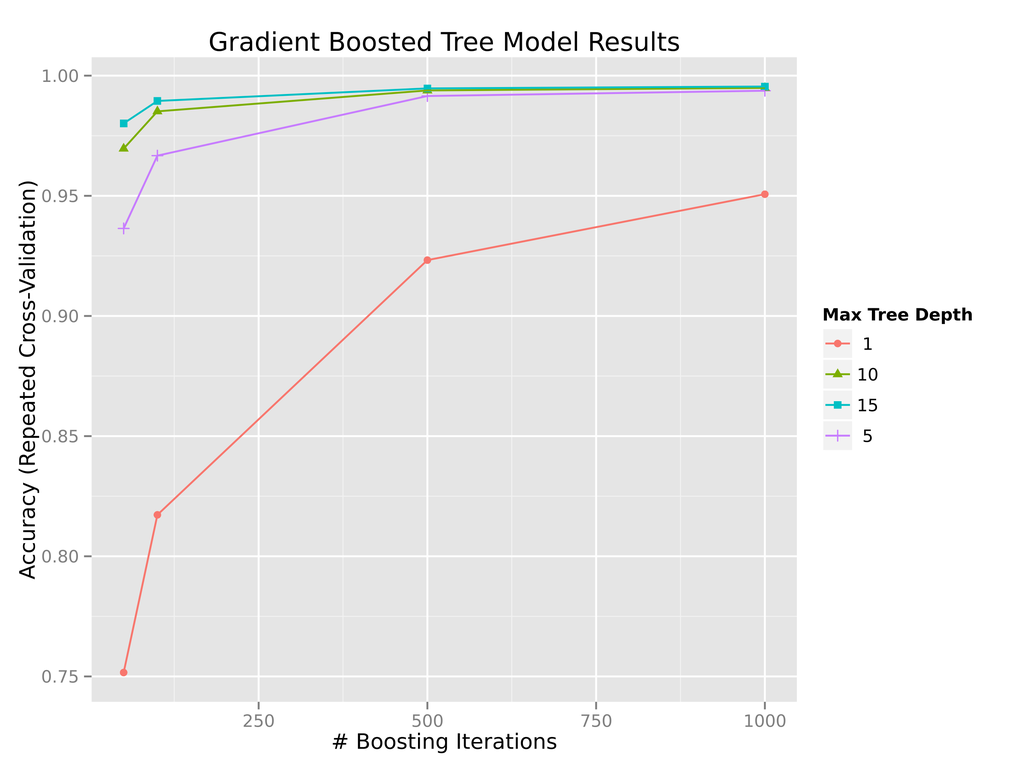

## 4.3 Support Vector Machines

Finally, we used support vector machines with radial basis kernel as our third candidate model. This proved interesting for number of reasons.

As with random forests and boosted trees above, we begin by creating a grid of tuning parameter values to be used in 5-fold cross-validation for model selection. The `caret` package has several impelementations of SVM, but here we use the radial basis kernel implementation that allows the specification of two meta-parameters: cost and sigma. The code below illustrates their values.

```r
svm_grid <- expand.grid(
    C = c(0.01, 0.5, 1, 2),
    sigma = c(1.0e-7, 1.0e-5, 0.001, 0.01, 0.1, 1.0)
)
```

The model fitting process took quite long, and the eventual results we not promising. Of all the possible combinations of cost and sigma, only in a few cases were the prediction accuracy on par with our early random forest and boosting models. In fact, it was only when sigma = 0.00001 and cost was 0.5 or 1.0 that we had competitive results.

In many cases, the classification accuracy was only slightly better than what we would expect by chance. This illustrates a very interesting point; support vector machines with radial basis kernels seem rather sensitive to the choise of tuning parameters.

Because even the best of our SVM models did not compete with our random forest or boosting models, we elected to omit this approach from consideration.

# 5 Conclusion

In the end, gradient boosted trees provided the best prediction accuracy—both in the cross-validation stage, as well as in our hold out training set.

Thus, we elect to keep this as our final model. But nonetheless, it is worth mentioning that both boosting and random forests did incredibly well—with both providing nearly perfect prediction in our hold-out set. In both cases, we would expect our out-of-sample error to be very near 0.5%.